# How to visualise data in R

# 12 Odd bits for sorting later

## 12.1 Vertical and horizontal lines

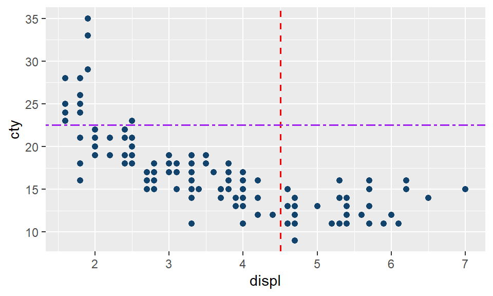

```r
mpg %>%
  ggplot(aes(x=displ, y = cty)) +
  geom_point() +
  geom_vline(xintercept = 4.5, colour = "red", linetype="dashed") +
  geom_hline(yintercept = 22.5, colour = "purple", linetype = "twodash")
```

### 12.1.1 Shading

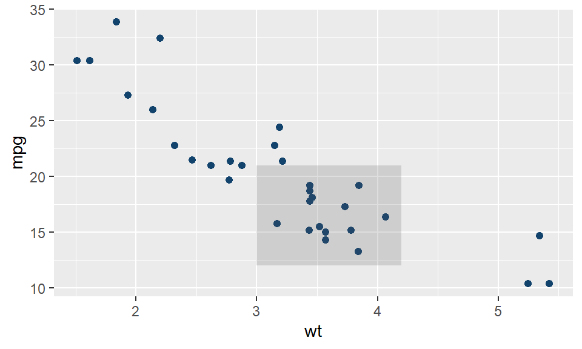

```r
# geom_rect
ggplot(mtcars, aes(x = wt, y = mpg)) + geom_point() +
     annotate("rect", xmin = 3, xmax = 4.2, ymin = 12, ymax = 21,
        alpha = .2)
```

```r
# to use with dates:
# annotate("rect", xmin = as.Date("2020-06-01"), xmax = as.Date("2021-06-01"), ymin = -Inf, ymax = Inf,
#           alpha = .2)
```

# 13 Dynamic plots

There may be cases where you want to produce multiple plots with the same geoms and structure but looking at a different outcome variable each time. Here it is more efficient to write a single function and repeat it. This can be made dynamic through use of `{{` and `deparse`:

```r
la_graph = function(data, outcome){

  # extract title passed to function for using in ggtitle later
  title = deparse(substitute(outcome))

  data %>%
    ggplot(aes(x = year, y = {{outcome}})) +
    theme_classic() +
    geom_line(aes(group = la_name), linewidth = 0.7, colour = "grey90") +
    stat_summary(fun = mean, geom = "line", aes(group = la_group, colour = la_group),
                 linewidth = 1) +
    theme(axis.text.x = element_text(angle=45, hjust = 1),
          axis.title.x = element_blank(),
          legend.title = element_blank()) +
    scale_y_continuous(labels = scales::label_percent(accuracy = 1, scale = 100),
                       limits = c(0,1)) +
    scale_x_continuous(breaks = 2013:2024, labels = function(x) substr(as.character(x), 3, 4))  +
    # invoke title object here
    ylab(title) +
    ggtitle(title)
}

# to run:
la_graph(dataset, outcome_of_interest)
```

# 14 Combining and saving plots

## 14.1 Facetting

To facet by a single variable, use `facet_wrap`. Add `scales = "free"` if axes are different for each group (or try `free_x` or `free_y`). NOTE: the old way was `~ species`, but `vars` allows you to specify several groupings, e.g. `vars(species, sex)`.

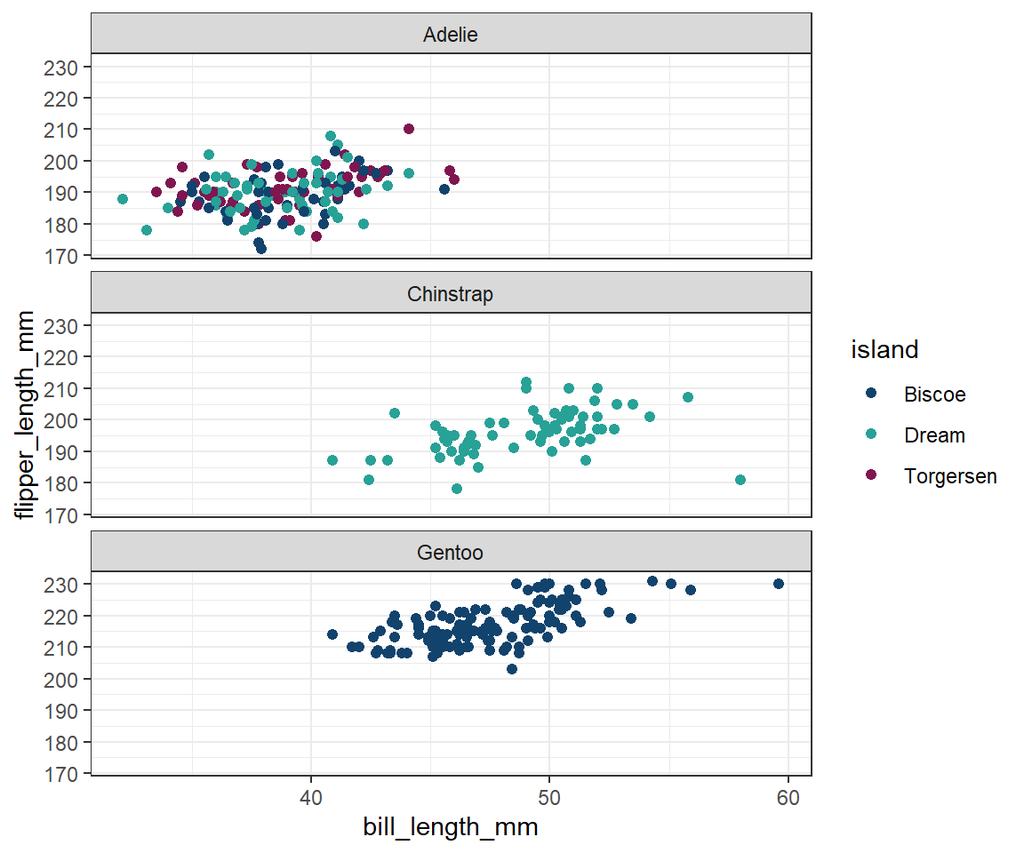

```r
palmerpenguins::penguins %>%
  ggplot(aes(x = bill_length_mm, y = flipper_length_mm)) +
  geom_point(aes(colour = island)) +
  facet_wrap(vars(species),
             nrow = 3,
             scales = "fixed") +
  # customisation of strips/panels:
  theme(strip.text = element_text(face = "bold", color = "black", hjust = 0.5, size = 10),
        strip.background = element_rect(fill = NA, linetype = "solid", color = "black")) +
  theme_bw()
```

To facet by two variables, use `facet_grid`. Note that you can automate this by providing a factor or grouping variable, e.g. `facet_grid(rows = vars(group))`.

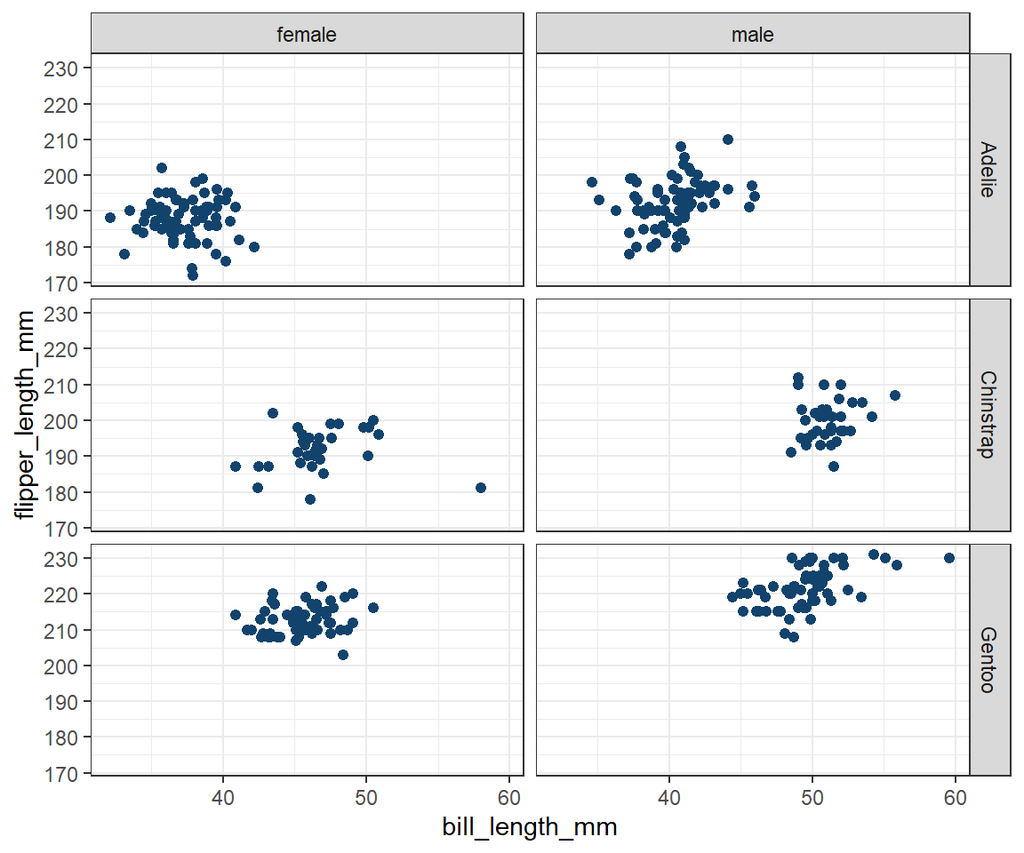

```r
palmerpenguins::penguins %>%
  drop_na(sex) %>%
  ggplot(aes(x=bill_length_mm, y=flipper_length_mm)) +
  geom_point() +
  facet_grid(species ~ sex,
             scales = "fixed") +
  theme_bw()
```

## 14.2 `patchwork`

```r
plots_obj

patchwork::wrap_plots(plots_obj,
                      nrow = 1,
                      ncol = 3)
```

## 14.3 `ggarrange`

Use `ggarrange` from the `ggpubr` package to arrange plots.

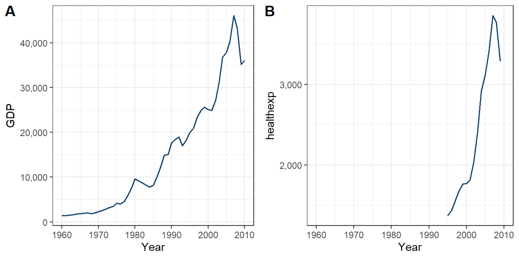

```r
# plot 1
a = gcookbook::countries %>%
    filter(Name == "United Kingdom") %>%
    ggplot(aes(x = Year, y = GDP)) +
    geom_line() +
    scale_y_continuous(labels = scales::label_comma(big.mark = ",")) +
    theme_bw()

# plot 2
b = gcookbook::countries %>%
    filter(Name == "United Kingdom") %>%
    ggplot(aes(x = Year, y = healthexp)) +
    geom_line() +
    scale_y_continuous(labels = scales::label_comma(big.mark = ",")) +
    theme_bw()

# combine
ggarrange(a, b,
          ncol=2,
          widths = c(1,1),
          labels = c("A", "B"))
```

You can also nest ggarrange calls, e.g. if you have 3 or more plots

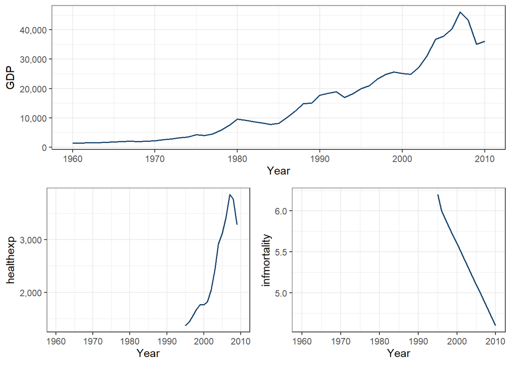

```r
c = gcookbook::countries %>%
    filter(Name == "United Kingdom") %>%
    ggplot(aes(x = Year, y = infmortality)) +
    geom_line() +
    theme_bw()

ggarrange(a,
          ggarrange(b, c, ncol = 2),
          nrow = 2)
```

It’s also possible to use a shared legend and title (if applicable to all plots)

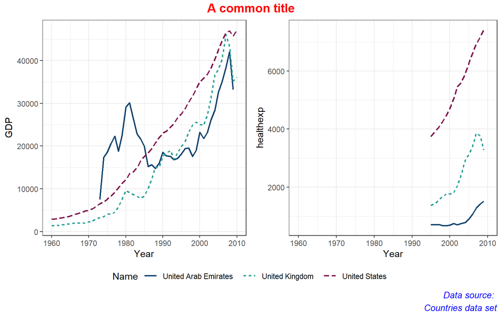

```r
a = gcookbook::countries %>%
    filter(str_detect(Name, "United")) %>%
    ggplot(aes(x = Year, y = GDP)) +
    geom_line(aes(colour = Name, linetype = Name), linewidth = 0.8) +
    theme_bw()

# plot 2
b = gcookbook::countries %>%
    filter(str_detect(Name, "United")) %>%
    ggplot(aes(x = Year, y = healthexp)) +
    geom_line(aes(colour = Name, linetype = Name), linewidth = 0.8) +
    theme_bw()

# wrap in annotate_figure for common title
annotate_figure(ggarrange(a, b, ncol=2,
          common.legend = T,
          legend = "bottom"),
    top = text_grob("A common title", color = "red", face = "bold", size = 14),
    bottom = text_grob("Data source: \n Countries data set", color = "blue",
                                  hjust = 1, x = 0.99, face = "italic", size = 10),
    fig.lab.pos = "top",
    fig.lab.size = 14)
```

Another recipe for a common legend. This comes from the English Hubs impact eval where there were 6 individual plots combined into a matrix plot. Each had its own legend which was inefficient. This recipe required one plot with all waves together so as to get a legend with all available values. Then a custom function is used to extract the legend from this. Aftwards, combine the individual plots with the extracted legend. Note that the recipe below is only useful if you want to make many pairwise comparisons, e.g. compare some level of a factor against some constant (in this case, compare control schools against each wave separately).

```r
# create plot with all values on it together
all = wave_plot_all(y1_schl)

# extract the legend from this
# from here: https://www.geeksforgeeks.org/r-language/add-common-legend-to-combined-ggplot2-plots-in-r/
get_only_legend <- function(plot) {
  plot_table <- ggplot_gtable(ggplot_build(plot))
  legend_plot <- which(sapply(plot_table$grobs, function(x) x$name) == "guide-box")
  legend <- plot_table$grobs[[legend_plot]]
  return(legend)
}

legend = get_only_legend(all)

# create the individual plots (this also uses a custom plotting function)
w1 = wave_plot_single(y1_schl, wave = 201920, "#12436D", "Wave 1", treatment_start = "2019-09-01")
w2 = ...

# combine these
combined_plot = grid.arrange(w1, w2, w3, w4, w5, w6)

# combine this with the extracted legend
grid.arrange(combined_plot, legend, nrow = 2, heights = c(10, 1))
```

Building on this further, if you would like to add a figure caption then there this is this rather convoluted example using the grid package and arrangeGrob. The below is a reproducible example.

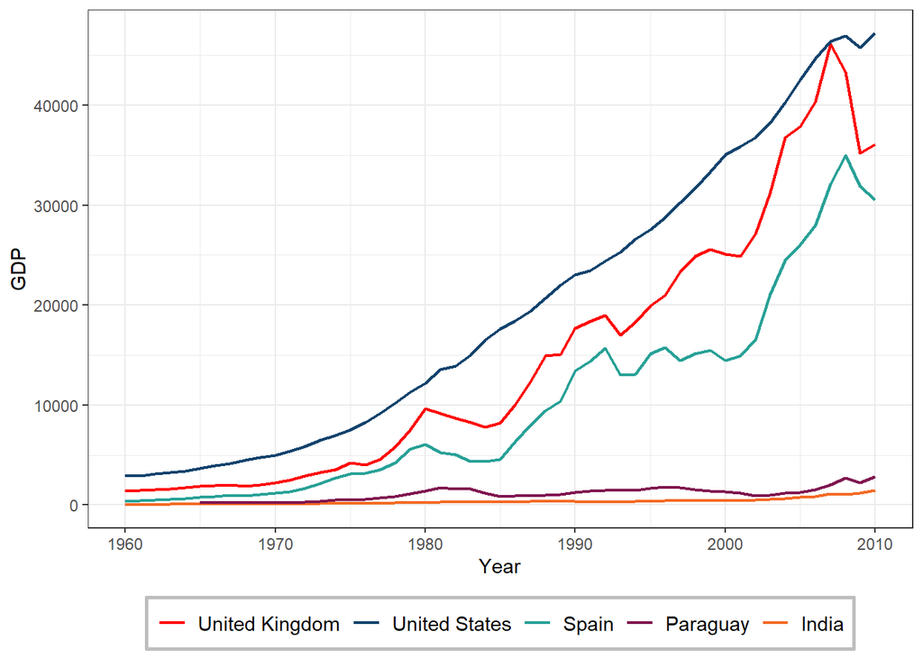

```r
# make plot with all
all = gcookbook::countries %>%
  filter(Name %in% c("United Kingdom", "United States", "Spain", "Paraguay",
                     "India")) %>%
  ggplot(aes(x = Year, y = GDP)) +
  geom_line(aes(colour = Name), linewidth = 0.8) +
  theme_bw() +
  scale_colour_manual(name = NULL,
                      values = c("red", "#12436D", "#28A197", "#801650", "#F46A25"),
                      breaks = c("United Kingdom", "United States", "Spain", "Paraguay",
                                 "India")) +
  theme(legend.position = "bottom",
        legend.text = element_text(size=11),
        legend.background = element_rect(colour = "grey", linewidth = 1)) +
  guides(colour = guide_legend(nrow = 1))
all
```

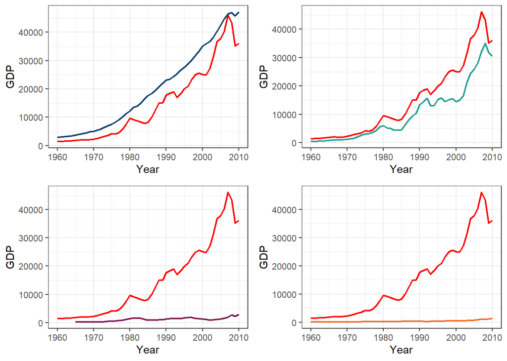

```r
# extract legend
get_only_legend <- function(plot) {
  plot_table <- ggplot_gtable(ggplot_build(plot))
  legend_plot <- which(sapply(plot_table$grobs, function(x) x$name) == "guide-box")
  legend <- plot_table$grobs[[legend_plot]]
  return(legend)
}

legend = get_only_legend(all)

# note: looks like ggpubr::get_legend can do this already
legend = ggpubr::get_legend(all)

# create individual plots
p1 = gcookbook::countries %>%
  filter(Name %in% c("United Kingdom", "United States")) %>%
  ggplot(aes(x = Year, y = GDP)) +
  geom_line(aes(colour = Name), linewidth = 0.8) +
  theme_bw() +
  theme(legend.position = "none") +
  scale_colour_manual(name = "Country",
                      values = c("red", "#12436D"),
                      breaks = c("United Kingdom", "United States"))

p2 = gcookbook::countries %>%
  filter(Name %in% c("United Kingdom", "Spain")) %>%
  ggplot(aes(x = Year, y = GDP)) +
  geom_line(aes(colour = Name), linewidth = 0.8) +
  theme_bw() +
  theme(legend.position = "none") +
  scale_colour_manual(name = "Country",
                      values = c("red", "#28A197"),
                      breaks = c("United Kingdom", "Spain"))

p3 = gcookbook::countries %>%
  filter(Name %in% c("United Kingdom", "Paraguay")) %>%
  ggplot(aes(x = Year, y = GDP)) +
  geom_line(aes(colour = Name), linewidth = 0.8) +
  theme_bw() +
  theme(legend.position = "none") +
  scale_colour_manual(name = "Country",
                      values = c("red", "#801650"),
                      breaks = c("United Kingdom", "Paraguay"))

p4 = gcookbook::countries %>%
  filter(Name %in% c("United Kingdom", "India")) %>%
  ggplot(aes(x = Year, y = GDP)) +
  geom_line(aes(colour = Name), linewidth = 0.8) +
  theme_bw() +
  theme(legend.position = "none") +
  scale_colour_manual(name = "Country",
                      values = c("red", "#F46A25"),
                      breaks = c("United Kingdom", "India"))

# combine
combined_plot = gridExtra::grid.arrange(p1, p2, p3, p4)
```

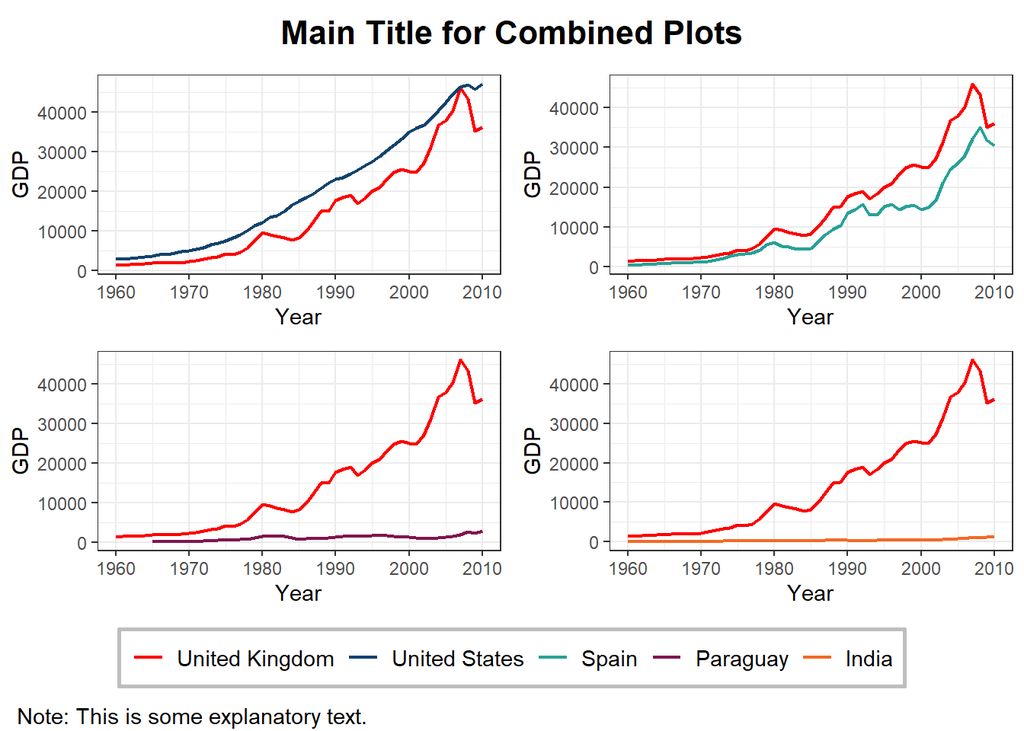

```r
# combine the individual plots, legend, a title, and a caption:
main_plot <- gridExtra::arrangeGrob(combined_plot, legend,
                         nrow = 2,
                         heights = c(10, 1.5))

title <- grid::textGrob("Main Title for Combined Plots",
                  gp = grid::gpar(fontsize = 16, fontface = "bold"),
                  hjust = 0.5, x = 0.5)

caption <- grid::textGrob("Note: This is some explanatory text.",
                    gp = grid::gpar(fontsize = 11),  # font size
                    hjust = -0.05,                 # left-align
                    x = 0)

final_plot <- gridExtra::arrangeGrob(title, main_plot, caption,
                          ncol = 1,
                          heights = c(0.1, 1, 0.05))

grid::grid.newpage()
grid::grid.draw(final_plot)
```

## 14.4 Saving

Files will be saved in your current working directory.

```r
my_plot = ggplot(...)

ppi = 300  # pixels per inch
png("file_name.png", width = 4*ppi, height = 4*ppi, res = ppi, bg = "white")
my_plot
dev.off()
```

## 14.5 Looping or iterating

Sometimes you want to produce the same graph for a range of different levels in a factor. This recipe below produces histograms, grouped by ‘EAL’ for every variable listed in the `covariates` vector. It uses `purrr::map` to iterate through this list and then invokes `cowplot::plot_grid` to add these all to one file.

```r
hist_group_fun = function(x, y = NA) {
  ggplot(data, aes(x = .data[[x]], fill = .data[[y]], colour = .data[[y]]) ) +
    geom_histogram(alpha=0.5, position = "identity") +
    theme(legend.text = element_text(size=9))
}

hist_group_fun(x = "IDACI.rank19", y = "EAL")

# make a list of variables to loop through
covariates = c("cpm.raw", "bpvs.raw", "IDACI.rank19")

# iterate through covariates
covariate_plots = map(covariates, ~ hist_group_fun(.x, "EAL") )

# save to a single pdf file
pdf("histograms_all.pdf")
cowplot::plot_grid(plotlist = covariate_plots)
dev.off()
```

Another way to achieve this is by converting variable names to symbols. The function below creates dodged bar plots (with the same y-axis value each time), and then the map function iterates through a list of grouping variables (`vars`) such that each time a new plot is produced with the next grouping factor in the vector. The function uses tidy evaluation (the unquote or ‘bang-bang’ character `!!`)

```r
bar_fun = function(data, var1, var2) {

  # convert grouping factors into symbols first
  var1 = sym(var1)
  var2 = sym(var2)

  data %>%
    filter(psc_pass == "Fail") %>%
    # the below effectively becomes group_by(c_summer_born, SEX)
    group_by(!!var1, !!var2) %>%
    summarise(PHONICSMARK = round(mean(PHONICSMARK, na.rm = TRUE), 1), .groups = "drop") %>%
    ggplot(aes(x = !!var1, y = PHONICSMARK, fill = !!var2)) +
    geom_bar(stat = "identity", position = position_dodge()) +
    geom_text(aes(label = PHONICSMARK),
              vjust = 1.2,
              position = position_dodge(width = 1),
              show.legend = T) +
    labs(title = paste("By", as_string(var2))) +
    theme_classic() +
    theme(axis.title = element_blank())
}

vars = c("SEX", "c_disad", "c_any_Sen", "c_white_british", "c_eal")

plots = purrr::map(vars, ~ bar_fun(data = ph_cen2, var1 = "c_summer_born", var2 = .x))

patchworK::wrap_plots(plots, ncol = 3)
```

This slightly different recipe takes an outcome variable and grouping factor to produce a histogram. It uses `enquo` to extract the number of levels in the specified grouping factor which it then supplies to the `nrow` argument of `facet_wrap`.

```r
dist_graph = function(data, x, char){

  # quote the 'char' variable
  char_var = enquo(char)

  # find unique number of values in 'char' by unquoting
  width = data %>%
    summarise(dist = n_distinct(!!char_var)) %>% as.numeric()

  data %>%
    ggplot(aes(x = {{x}}, fill = {{char}})) +
    geom_histogram(binwidth = 1, position  = "identity") +
    facet_wrap(vars({{char}}),
               scales = "free",
               nrow = width) +
    theme(legend.position = "none",
          axis.title.y = element_blank()) +
    geom_vline(xintercept = 32, colour = "red")
}

dist_graph(c1_c2, x = PHONICSMARK_y1, char = MoB)
```